# heat

Jon Woodring

May 2, 2017

# Heat in dplyr

The program is pretty much the same as the Spark version, and this is just a stunt to show how similar the programming is.

Also, to show you how the dplyr (Spark) compiles into SQL commands.

```r
library(dplyr)
```

```r
library(RSQLite)
library(ggplot2)

if (!dir.exists("./images"))
{
  dir.create("./images")
}
if (file.exists("./heat.db"))
{
  file.remove("./heat.db")
}
```

```
## [1] TRUE
```

```r
db <- src_sqlite("./heat.db", create=TRUE)
dbGetQuery(db $ con, "pragma journal=memory")
```

```
## data frame with 0 columns and 0 rows
```

```r
dbGetQuery(db $ con, "pragma synchronize=off")
```

```
## data frame with 0 columns and 0 rows
```

```r
dbGetQuery(db $ con, "pragma threads=4")
```

```
##   threads
## 1       4
```

## grid

We create our is and js such that we have a list of `uid` to i, j positions.

One difference between Spark is that we have different types of joins, like `inner_join`.

```r
x <- 202
y <- 202

is <- copy_to(db, data.frame(i=1:x-1))
js <- copy_to(db, data.frame(j=1:y-1))
grid <- is %>%
  mutate(dummy = 1) %>%
  inner_join(js %>% mutate(dummy = 1)) %>%
  select(-dummy) %>%
  mutate(uid=i + j * x)
explain(grid)
```

```
## <SQL>
## SELECT `i`, `j`, `i` + `j` * 202.0 AS `uid`
## FROM (SELECT `i` AS `i`, `j` AS `j`
## FROM (SELECT * FROM (SELECT `i`, 1.0 AS `dummy`
## FROM `data.frame(i = 1:x - 1)`)
##
## INNER JOIN
##
## (SELECT `j`, 1.0 AS `dummy`
## FROM `data.frame(j = 1:y - 1)`)
##
## USING (`dummy`)))
```

[output not shown]

```r
grid <- grid %>%
  compute(name="grid", unique_indexes=list("uid"))
grid
```

```
## Source:   query [?? x 3]
## Database: sqlite 3.16.2 [./heat.db]
##
## # A tibble: ?? x 3
##        i     j   uid
##    <dbl> <dbl> <dbl>
##  1     0     0     0
##  2     0     1   202
##  3     0     2   404
##  4     0     3   606
##  5     0     4   808
##  6     0     5  1010
##  7     0     6  1212
##  8     0     7  1414
##  9     0     8  1616
## 10     0     9  1818
## # ... with more rows
```

## topology and stencil

For the `stencil`, we individually create each direction, somewhat similar to how we did it in Thrust, but instead of zipping the columns together, we union them into one table, creating the topology, `topo`.

It would be possible to zip them together, like Thrust, but that creates a problem if you want to create topologies that aren’t always 4-way. By creating a list, i.e., (uid, adjacent) keyed by uid, we can have arbitrary topologies, like points, triangles, tetrahedra, etc.

```r
non_boundary <- grid %>%
  filter(i > 0 && i < x-1 && j > 0 && j < y-1)
left <- non_boundary %>% mutate(a=i-1, b=j) %>% select(-i, -j)
right <- non_boundary %>% mutate(a=i+1, b=j) %>%  select(-i, -j)
top <- non_boundary %>%  mutate(a=i, b=j+1) %>% select(-i, -j)
bottom <- non_boundary %>%  mutate(a=i, b=j-1) %>% select(-i, -j)
stencil <- left %>%
  union_all(right) %>%
  union_all(top) %>%
  union_all(bottom)
topo <- stencil %>%
  left_join(grid, c("a"="i", "b"="j")) %>%
  mutate(uid=uid.x, adj=uid.y) %>%
  select(-a, -b, -i, -j, -uid.x, -uid.y)
explain(topo)
```

```
## <SQL>
## SELECT `uid` AS `uid`, `adj` AS `adj`
## FROM (SELECT `uid.x`, `a`, `b`, `i`, `j`, `uid.y`, `uid.x` AS `uid`, `uid.y` AS `adj`
## FROM (SELECT * FROM (SELECT `uid` AS `uid.x`, `a` AS `a`, `b` AS `b`
## FROM (SELECT `uid` AS `uid`, `a` AS `a`, `b` AS `b`
## FROM (SELECT `i`, `j`, `uid`, `i` - 1.0 AS `a`, `j` AS `b`
## FROM (SELECT *
## FROM (SELECT *
## FROM `grid`)
## WHERE (`i` > 0.0 AND `i` < 202.0 - 1.0 AND `j` > 0.0 AND `j` < 202.0 - 1.0)))
## UNION ALL
## SELECT `uid` AS `uid`, `a` AS `a`, `b` AS `b`
## FROM (SELECT `i`, `j`, `uid`, `i` + 1.0 AS `a`, `j` AS `b`
## FROM (SELECT *
## FROM (SELECT *
## FROM `grid`)
## WHERE (`i` > 0.0 AND `i` < 202.0 - 1.0 AND `j` > 0.0 AND `j` < 202.0 - 1.0)))
## UNION ALL
## SELECT `uid` AS `uid`, `a` AS `a`, `b` AS `b`
## FROM (SELECT `i`, `j`, `uid`, `i` AS `a`, `j` + 1.0 AS `b`
## FROM (SELECT *
## FROM (SELECT *
## FROM `grid`)
## WHERE (`i` > 0.0 AND `i` < 202.0 - 1.0 AND `j` > 0.0 AND `j` < 202.0 - 1.0)))
## UNION ALL
## SELECT `uid` AS `uid`, `a` AS `a`, `b` AS `b`
## FROM (SELECT `i`, `j`, `uid`, `i` AS `a`, `j` - 1.0 AS `b`
## FROM (SELECT *
## FROM (SELECT *
## FROM `grid`)
## WHERE (`i` > 0.0 AND `i` < 202.0 - 1.0 AND `j` > 0.0 AND `j` < 202.0 - 1.0)))))
##
## LEFT JOIN
##
## (SELECT `i` AS `i`, `j` AS `j`, `uid` AS `uid.y`
## FROM `grid`)
##
## ON (`a` = `i` AND `b` = `j`)))
```

[output not shown]

[output cut: 105 more lines]

```r
topo <- topo %>%
  compute(name="topo", indexes=list("uid"))
topo
```

```
## Source:   query [?? x 2]
## Database: sqlite 3.16.2 [./heat.db]
##
## # A tibble: ?? x 2
##      uid   adj
##    <dbl> <dbl>
##  1   203   202
##  2   405   404
##  3   607   606
##  4   809   808
##  5  1011  1010
##  6  1213  1212
##  7  1415  1414
##  8  1617  1616
##  9  1819  1818
## 10  2021  2020
## # ... with more rows
```

## initialization

`dplyr` is nice in that it gives us a sampling function, `sample_n`, allowing us to sampling from the non boundary grid points. We use the sample to mutate them with the initial heat to union them back into the heat table, `current`, and reduce the temperatures by key, i.e., `group_by` and `summarize`.

```r
add_random_heat <- non_boundary %>%
  collect() %>%
  sample_n(4) %>%
  mutate(heat=1) %>%
  select(-i, -j)
current <- grid %>%
  mutate(heat=0) %>%
  select(-i, -j) %>%
  union_all(add_random_heat, copy=TRUE) %>%
  group_by(uid) %>%
  summarize(heat=sum(heat))
explain(current)
```

```
## <SQL>
## SELECT `uid`, SUM(`heat`) AS `heat`
## FROM (SELECT `uid` AS `uid`, `heat` AS `heat`
## FROM (SELECT `i`, `j`, `uid`, 0.0 AS `heat`
## FROM (SELECT *
## FROM `grid`))
## UNION ALL
## SELECT *
## FROM `unruktrxun`)
## GROUP BY `uid`
```

[output not shown]

[output cut: 46 more lines]

```r
current <- current %>%
  compute(name="current")
```

```r
current %>% filter(heat > 0)
```

```
## Source:   query [?? x 2]
## Database: sqlite 3.16.2 [./heat.db]
##
## # A tibble: ?? x 2
##     uid  heat
##   <dbl> <dbl>
## 1  5468     1
## 2 16215     1
## 3 16588     1
## 4 37993     1
```

## update_step

The `update_step` is the same as Spark.

```r
update_step <- function(current)
{
  neighbors <- topo %>%
    inner_join(current, c("adj"="uid")) %>%
    mutate(heat=heat*0.125, center=uid.x) %>%
    select(-adj, -uid.x, -uid.y)
  current %>%
    mutate(heat=heat*0.5, center=uid) %>%
    select(-uid) %>%
    union_all(neighbors) %>%
    group_by(center) %>%
    summarize(heat=sum(heat)) %>%
    mutate(uid=center)
}
explain(update_step(current))
```

```
## <SQL>
## SELECT `center`, `heat`, `center` AS `uid`
## FROM (SELECT `center`, SUM(`heat`) AS `heat`
## FROM (SELECT `heat` AS `heat`, `center` AS `center`
## FROM (SELECT `uid`, `heat` * 0.5 AS `heat`, `uid` AS `center`
## FROM (SELECT *
## FROM `current`))
## UNION ALL
## SELECT `heat` AS `heat`, `center` AS `center`
## FROM (SELECT `uid.x`, `adj`, `uid.y`, `heat` * 0.125 AS `heat`, `uid.x` AS `center`
## FROM (SELECT * FROM (SELECT `uid` AS `uid.x`, `adj` AS `adj`
## FROM (SELECT *
## FROM `topo`))
##
## INNER JOIN
##
## (SELECT `uid` AS `uid.y`, `heat` AS `heat`
## FROM (SELECT *
## FROM `current`))
##
## ON (`adj` = `uid.y`))))
## GROUP BY `center`)
```

[output not shown]

[output cut: 64 more lines]

```r
update_step(current) %>% filter(heat > 0)
```

```
## Source:   query [?? x 3]
## Database: sqlite 3.16.2 [./heat.db]
##
## # A tibble: ?? x 3
##    center  heat   uid
##     <dbl> <dbl> <dbl>
##  1   5266 0.125  5266
##  2   5467 0.125  5467
##  3   5468 0.500  5468
##  4   5469 0.125  5469
##  5   5670 0.125  5670
##  6  16013 0.125 16013
##  7  16214 0.125 16214
##  8  16215 0.500 16215
##  9  16216 0.125 16216
## 10  16386 0.125 16386
## # ... with more rows
```

## write_output

We can directly write the output back into a table by using some SQL to select the existing table into a new table. We can directly plot the data since we are in R.

```r
write_output <- function(t)
{
  dbGetQuery(db $ con,
    paste("create table output_0_", t,
          " as select grid.i as i, grid.j as j, heat from current, grid where current.uid = grid.uid",
          " and i > 0 and i <= ", x-2,
          " and j > 0 and j <= ", y-2, sep=""))
  tbl(db, paste("output_0_", t, sep="")) %>%
    collect() %>%
    ggplot() +
    aes(x=i, y=j, fill=heat) +
    geom_raster() +
    ggsave(paste("images/output_0_", t, ".png", sep="")) +
    scale_color_gradient()
}
```

## heat program

What’s different here from Spark is that we use double-buffering to flip between tables. This is because name bindings are global, and we need to drop the old table names and rename to the existing table name.

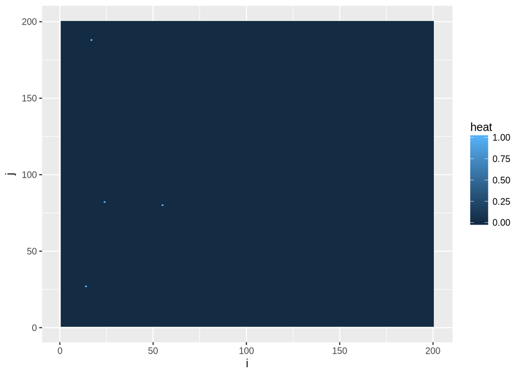

```r
write_output(0)
```

```r
for (t in 1:100)
{
  nexts <- update_step(current) %>% compute(name="next")
  sink <- dbGetQuery(db $ con, "drop table current")
  sink <- dbGetQuery(db $ con, "alter table next rename to current")
  current <- tbl(db, "current")

  if (t %% 100 == 0) write_output(t)
}
```

[output not shown]

[output cut: 847 more lines]

[output not shown]